**Research Question:** "How do POTS patients in the Long COVID community compare to the broader population in terms of symptom burden, treatment patterns, co-occurring conditions, and reported outcomes?"

# POTS in the Long COVID Community: A Preliminary Comparative Analysis

*Study type: Preliminary / survey study. Findings are hypothesis-generating.*

## 1. Data Exploration and Cohort Definition

Data covers: **2026-03-11 to 2026-04-10 (1 month)** from r/covidlonghaulers.

We define two non-overlapping cohorts based on extracted condition mentions:

- **POTS cohort**: Users with at least one extracted condition of "pots" (including "postural orthostatic tachycardia").
- **Non-POTS cohort**: All remaining users in the community.

This is an extraction-based classification -- the NLP pipeline must have identified POTS as a condition for that user, not merely that the user typed the word "pots" in a post. Some misclassification is inevitable (see Limitations).

| Cohort | Users | % of Community | Median Posts/User | Users w/ Treatment Reports | Median Treatments Tried | Median Conditions |
| --- | --- | --- | --- | --- | --- | --- |
| POTS | 80 | 2.8% | 13 | 51 | 5 | 8 |
| Non-POTS | 2747 | 97.2% | 2 | 1070 | 3 | 2 |

**Verbose processing note:** The POTS cohort includes 80 users identified via condition extraction (condition_name matching "pots" or "postural orthostatic tachycardia"). Of these, 51 have at least one treatment report. The non-POTS cohort contains 2,747 users, of whom 1,070 filed treatment reports. POTS users represent 2.8% of the community but 4.6% of treatment reporters, indicating higher engagement with treatment experimentation.

## 2. Baseline: Overall Treatment Outcomes

Before examining specific treatments, we establish whether POTS users experience different outcomes in aggregate. We compute a user-level average sentiment score (positive=1, mixed=0.5, neutral=0, negative=-1) across all treatment reports for each user, then compare the two cohorts.

|  | POTS (n=51) | Non-POTS (n=1070) | Test |
| --- | --- | --- | --- |
| Mean sentiment score | 0.182 | 0.394 | Mann-Whitney U=20626, p=0.0022, r<sub>rb</sub>=0.244 |
| % users with positive avg | 64.7% [51.0%, 76.4%] | 71.5% [68.7%, 74.1%] | Fisher OR=0.73, p=0.3419, Cohen h=-0.146 |

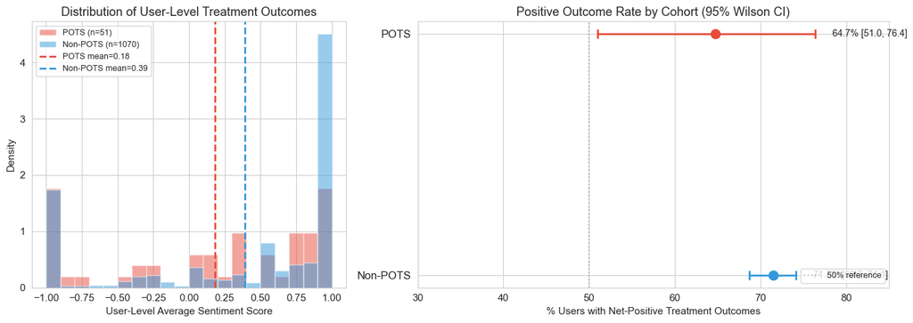

In plain language: if you picked a random POTS user and a random non-POTS user, the POTS user would report worse treatment outcomes roughly 60% of the time. This is a preliminary finding from a single community -- it could reflect genuinely harder-to-treat physiology, or it could reflect the higher symptom burden making any single treatment less satisfying.

## 3. Co-Occurring Conditions: The POTS Constellation

POTS users in this community carry a median of 8 co-occurring conditions vs 2 for non-POTS users. This section examines which conditions cluster with POTS and whether this pattern differs from the broader community's comorbidity profile. We filter "long covid" as the community-defining condition (per filtering rules).

Co-Occurring Condition Prevalence: POTS vs Non-POTS

| condition | POTS n | POTS % | Non-POTS n | Non-POTS % | Prevalence Ratio | Fisher OR | p-value |
| --- | --- | --- | --- | --- | --- | --- | --- |
| pem | 64 | 80.0% | 24 | 0.9% | 91.6x | 453.8 | <0.0001 |
| mcas | 57 | 71.2% | 18 | 0.7% | 108.7x | 375.7 | <0.0001 |
| dysautonomia | 51 | 63.7% | 8 | 0.3% | 218.9x | 602.1 | <0.0001 |
| me/cfs | 48 | 60.0% | 10 | 0.4% | 164.8x | 410.6 | <0.0001 |
| post-viral | 35 | 43.8% | 10 | 0.4% | 120.2x | 212.9 | <0.0001 |
| ehlers-danlos syndrome | 27 | 33.8% | 1 | 0.0% | 927.1x | 1398.9 | <0.0001 |
| ms | 23 | 28.7% | 4 | 0.1% | 197.4x | 276.7 | <0.0001 |
| covid related | 22 | 27.5% | 1 | 0.0% | 755.4x | 1041.6 | <0.0001 |
| ibs | 19 | 23.8% | 2 | 0.1% | 326.2x | 427.5 | <0.0001 |
| fibromyalgia | 19 | 23.8% | 1 | 0.0% | 652.4x | 855.3 | <0.0001 |
| small fiber neuropathy | 14 | 17.5% | 3 | 0.1% | 160.2x | 194.0 | <0.0001 |
| mast cell activation | 14 | 17.5% | 2 | 0.1% | 240.4x | 291.1 | <0.0001 |
| lupus | 13 | 16.2% | 0 | 0.0% | 1625.0x | inf | <0.0001 |
| lyme disease | 12 | 15.0% | 0 | 0.0% | 1500.0x | inf | <0.0001 |
| autonomic dysfunction | 12 | 15.0% | 3 | 0.1% | 137.3x | 161.4 | <0.0001 |
| gastroparesis | 10 | 12.5% | 0 | 0.0% | 1250.0x | inf | <0.0001 |
| covid induced | 9 | 11.2% | 0 | 0.0% | 1125.0x | inf | <0.0001 |
| ra | 8 | 10.0% | 0 | 0.0% | 1000.0x | inf | <0.0001 |
| fnd | 7 | 8.8% | 0 | 0.0% | 875.0x | inf | <0.0001 |
| endometriosis | 7 | 8.8% | 1 | 0.0% | 240.4x | 263.3 | <0.0001 |
| rheumatoid arthritis | 6 | 7.5% | 0 | 0.0% | 750.0x | inf | <0.0001 |
| cirs | 6 | 7.5% | 0 | 0.0% | 750.0x | inf | <0.0001 |
| multiple sclerosis | 5 | 6.2% | 0 | 0.0% | 625.0x | inf | <0.0001 |
| fibro | 5 | 6.2% | 0 | 0.0% | 625.0x | inf | <0.0001 |
| chronic lyme | 5 | 6.2% | 0 | 0.0% | 625.0x | inf | <0.0001 |

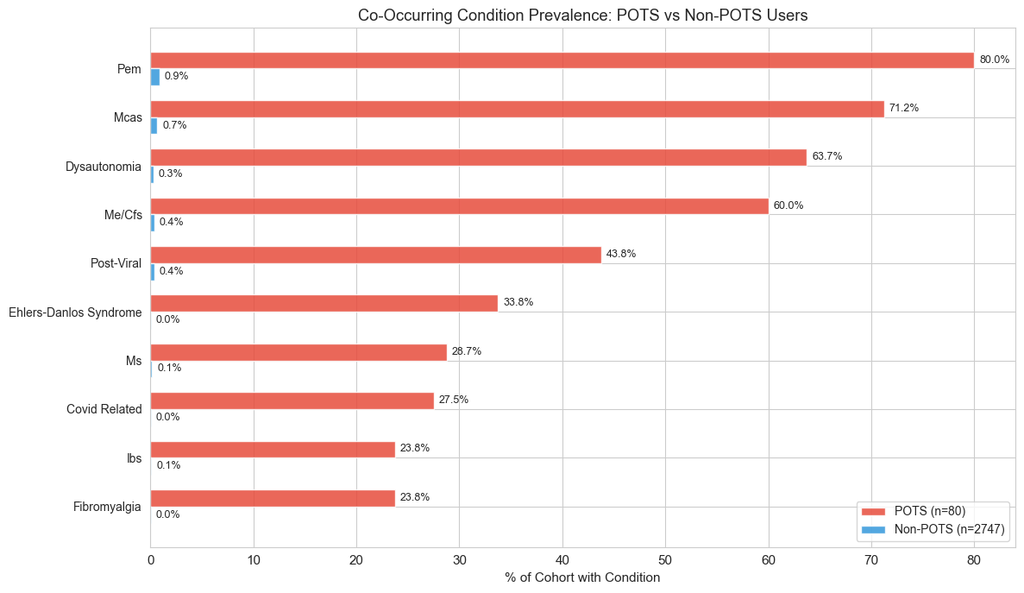

**What this shows:** POTS users have dramatically higher rates of nearly every comorbidity compared to non-POTS users. The strongest associations are with other autonomic and immune conditions: PEM (post-exertional malaise, a hallmark of ME/CFS where physical or mental exertion causes disproportionate symptom worsening), MCAS (mast cell activation syndrome, a condition where mast cells release excessive chemical mediators causing multi-system symptoms), dysautonomia (the broader category of autonomic nervous system dysfunction that includes POTS), and ME/CFS (myalgic encephalomyelitis/chronic fatigue syndrome). This is consistent with the clinical literature describing a "triad" of POTS + MCAS + EDS (Ehlers-Danlos Syndrome, a connective tissue disorder), all of which appear here.

POTS users report worse outcomes overall (Section 2). Which treatments drive that gap? This section compares treatment-level positive rates between the two cohorts for treatments where at least 4 POTS users reported.

We exclude generic terms (supplements, medication, antibiotics, antihistamines) and causal-context drugs (vaccines, which are discussed as potential triggers in this community rather than treatments). We merge famotidine/pepcid as duplicate canonicals.

**Verbose note:** 16 treatments with >= 4 POTS users after filtering generics and causal-context drugs.

## 4. Treatment Landscape Comparison

Treatment Outcomes: POTS vs Non-POTS (User-Level Positive Rate)

| Treatment | POTS Users | POTS Pos Rate | Non-POTS Users | Non-POTS Pos Rate | Difference | Fisher p | Cohen's h |
| --- | --- | --- | --- | --- | --- | --- | --- |
| Vitamin D | 9 | 67% [35, 88] | 51 | 80% [68, 89] | -14 pp | 0.392 | -0.31 |
| Coq10 | 8 | 50% [22, 78] | 54 | 59% [46, 71] | -9 pp | 0.710 | -0.19 |
| Low Dose Naltrexone | 7 | 57% [25, 84] | 176 | 68% [60, 74] | -10 pp | 0.685 | -0.22 |
| Magnesium | 7 | 100% [65, 100] | 49 | 90% [78, 96] | +10 pp | 1.000 | 0.65 |
| Nattokinase | 7 | 29% [8, 64] | 43 | 60% [46, 74] | -32 pp | 0.217 | -0.65 |
| Ketotifen | 7 | 71% [36, 92] | 30 | 67% [49, 81] | +5 pp | 1.000 | 0.10 |
| Electrolyte | 6 | 83% [44, 97] | 34 | 85% [70, 94] | -2 pp | 1.000 | -0.05 |
| Probiotics | 6 | 83% [44, 97] | 40 | 70% [55, 82] | +13 pp | 0.659 | 0.32 |
| Ssri | 5 | 40% [12, 77] | 45 | 38% [25, 52] | +2 pp | 1.000 | 0.05 |
| N-Acetylcysteine | 5 | 80% [38, 96] | 36 | 67% [50, 80] | +13 pp | 1.000 | 0.30 |
| Famotidine | 7 | 14% [3, 51] | 58 | 71% [58, 81] | -56 pp | 0.006 | -1.22 |
| Escitalopram | 4 | 0% [0, 49] | 10 | 60% [31, 83] | -60 pp | 0.085 | -1.77 |
| Beta Blocker | 4 | 50% [15, 85] | 33 | 70% [53, 83] | -20 pp | 0.582 | -0.40 |
| Nicotine | 4 | 75% [30, 95] | 78 | 63% [52, 73] | +12 pp | 1.000 | 0.26 |
| Red Light Therapy | 4 | 100% [51, 100] | 17 | 53% [31, 74] | +47 pp | 0.131 | 1.51 |
| Quercetin | 4 | 75% [30, 95] | 24 | 96% [80, 99] | -21 pp | 0.270 | -0.64 |

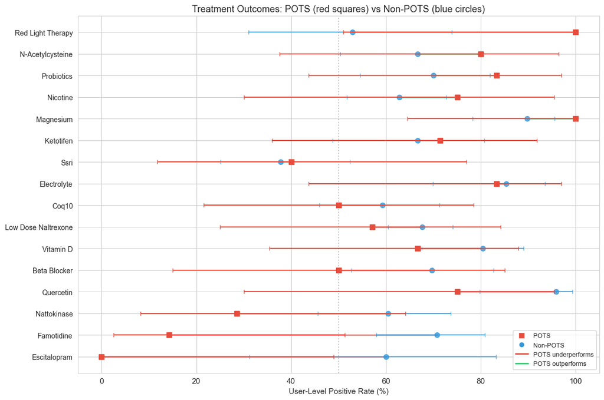

## 5. Multivariate Analysis: Does POTS Predict Worse Outcomes After Adjusting for Condition Burden?

POTS users carry far more co-occurring conditions. Is their worse outcome explained entirely by disease burden, or does POTS itself add independent predictive value? We use logistic regression with the binary outcome "user had net-positive treatment experience" (avg sentiment > 0) as the dependent variable.

Logistic Regression: Predictors of Net-Positive Treatment Outcome

| Variable | Odds Ratio | 95% CI Lower | 95% CI Upper | p-value |
| --- | --- | --- | --- | --- |
| Intercept | 2.050 | 1.719 | 2.443 | 0.0000 |
| POTS status | 0.874 | 0.285 | 2.682 | 0.8140 |
| N conditions | 0.960 | 0.866 | 1.063 | 0.4312 |
| N treatments tried | 1.051 | 1.020 | 1.084 | 0.0012 |

Pseudo R-squared: 0.0103 | AIC: 1340.4 | n=1121

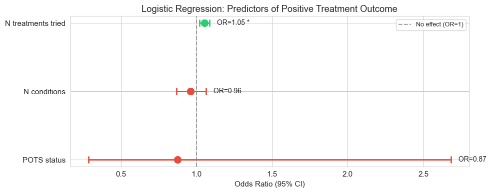

**What this shows:** The logistic regression tests whether POTS status predicts worse outcomes above and beyond condition burden and treatment count. The key question is whether the POTS odds ratio is significantly below 1.0 after adjusting for the number of co-occurring conditions and the number of treatments tried.

This matters because POTS users could have worse outcomes simply because they are sicker (more conditions) or because they have tried more things (treatment fatigue). If the POTS coefficient remains significant after adjustment, it suggests something specific about POTS -- not just general illness severity -- is associated with worse treatment response in this community.

## 6. Condition Co-Occurrence Heatmap

POTS users carry a median of 8 conditions. Which conditions travel together? This heatmap shows Jaccard similarity (the proportion of users with both conditions out of users with either condition) for the top conditions among POTS users.

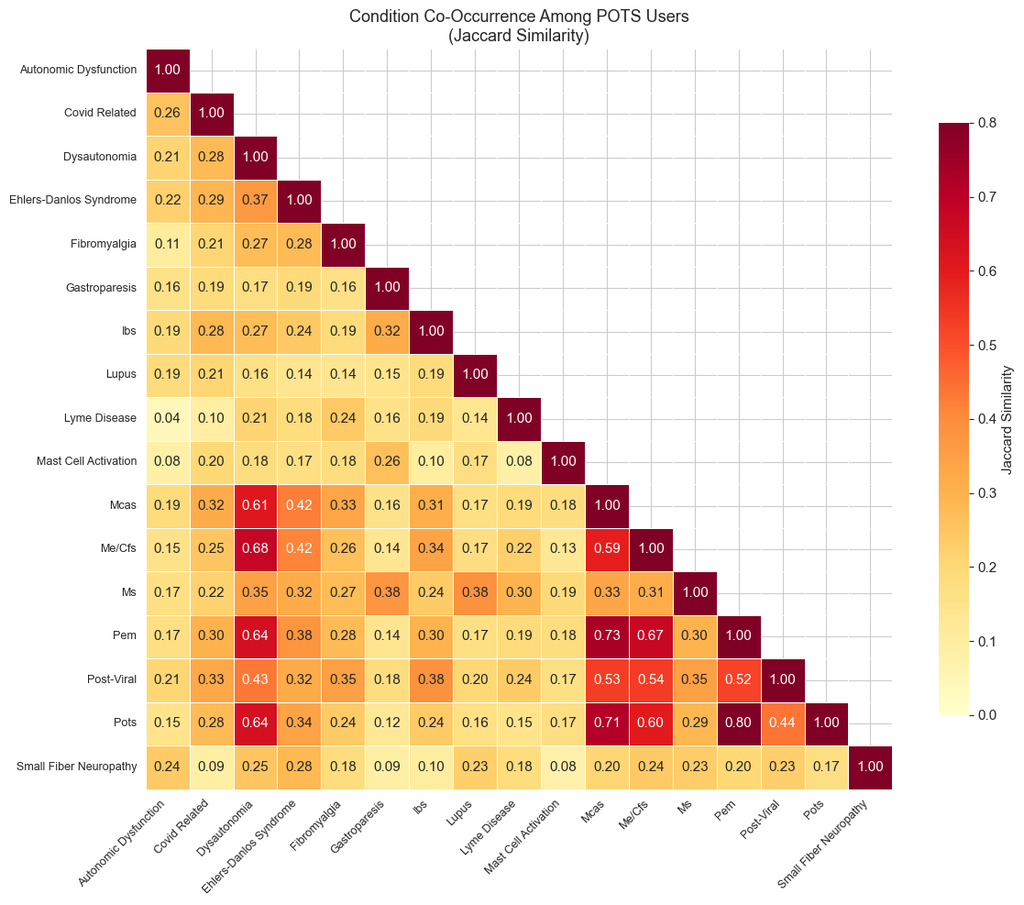

## 7. Polypharmacy and Community Engagement

POTS users try more treatments (median 5 vs 3 for non-POTS). Does trying more treatments correlate with better or worse outcomes? And does POTS status modify that relationship?

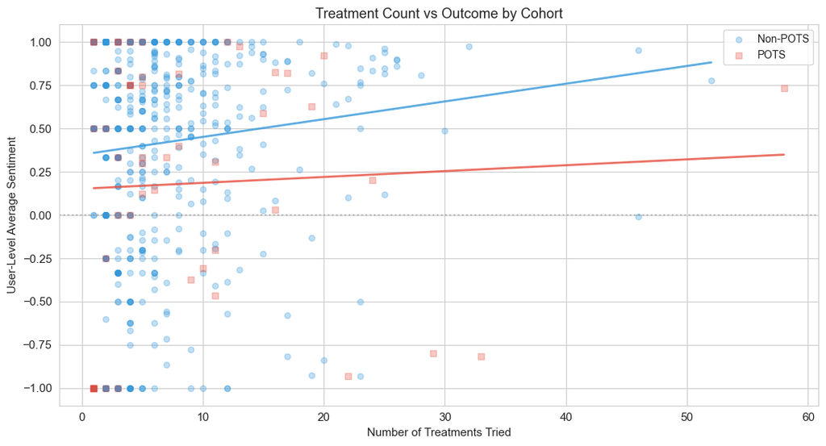

[output not shown]

**What this shows:** The scatter plot and correlation test reveal whether more treatment experimentation is associated with better or worse outcomes. A negative correlation would suggest "treatment fatigue" -- users who try many things do so because nothing works. A positive or null correlation would suggest that breadth of experimentation is not inherently harmful.

The POTS trend line and correlation coefficient are particularly important: if POTS users who try many treatments have worse outcomes than those who try few, it may indicate that the POTS subtype is genuinely harder to treat, not just that these users are more desperate.

## 8. Experiential Themes: What POTS Users Talk About

Beyond treatment reports, how does the POTS community's discourse differ from the broader community? We search post text for experiential themes and compare prevalence rates.

Experiential Theme Prevalence: POTS vs Non-POTS

| Theme | POTS n | POTS % | Non-POTS n | Non-POTS % | Ratio | Fisher p |
| --- | --- | --- | --- | --- | --- | --- |
| Dizziness | 17 | 21.2% | 81 | 2.9% | 7.2x | <0.0001 |
| Fear/Anxiety | 28 | 35.0% | 196 | 7.1% | 4.9x | <0.0001 |
| Heart/Palpitations | 16 | 20.0% | 166 | 6.0% | 3.3x | <0.0001 |
| Brain Fog | 34 | 42.5% | 384 | 14.0% | 3.0x | <0.0001 |
| Exercise/Activity | 27 | 33.8% | 312 | 11.4% | 3.0x | <0.0001 |
| Sleep | 32 | 40.0% | 418 | 15.2% | 2.6x | <0.0001 |
| Pain | 45 | 56.2% | 603 | 22.0% | 2.6x | <0.0001 |
| Isolation | 15 | 18.8% | 204 | 7.4% | 2.5x | 0.0009 |
| Fatigue | 51 | 63.7% | 699 | 25.4% | 2.5x | <0.0001 |
| Doctor/Provider | 47 | 58.8% | 692 | 25.2% | 2.3x | <0.0001 |
| Dismissed | 3 | 3.8% | 52 | 1.9% | 2.0x | 0.2026 |
| Recovery | 48 | 60.0% | 872 | 31.7% | 1.9x | <0.0001 |

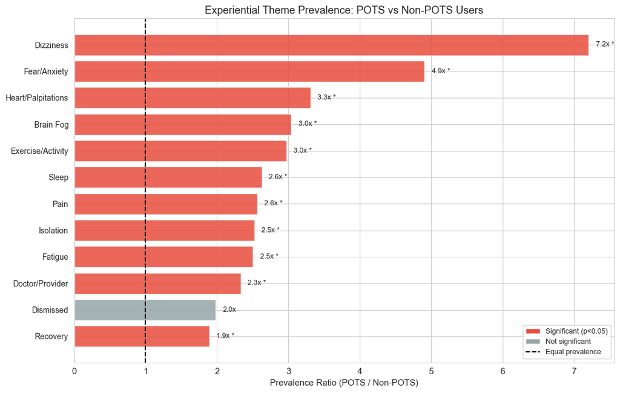

## 9. Treatment Agreement Analysis (Shannon Entropy)

For treatments reported by multiple POTS users, how much do those users agree? Shannon entropy measures the diversity of sentiment for each treatment -- low entropy means users agree (all positive or all negative), high entropy means opinions are split. This helps distinguish "reliably good" treatments from "works for some, not others."

[figure not shown]

**What this shows:** The entropy-effectiveness scatter identifies four quadrants:

- **Top-left (high positive rate, low entropy):** Treatments where POTS users agree they work. These are the strongest signals.
- **Top-right (high positive rate, high entropy):** Works for some users but not others -- individual response varies.
- **Bottom-left (low positive rate, low entropy):** Users agree it does not work. Clear negative signal.
- **Bottom-right (low positive rate, high entropy):** Mixed reception -- some users report benefit, others harm.

The most actionable findings are in the top-left (reliable positive treatments) and bottom-left (reliable negative -- treatments to approach cautiously in POTS).

## 10. Counterintuitive Findings Worth Investigating

Finding 1: Nattokinase Dramatically Underperforms for POTS Users

Nattokinase (a fibrinolytic enzyme promoted for microclot dissolution) shows 29% positive rate among POTS users (n=7) vs 60% among non-POTS users (n=43). Fisher's exact OR=0.26, p=0.217.

This is notable because nattokinase is one of the most-discussed treatments in the Long COVID community, often recommended for its microclot-dissolving properties. Yet POTS users -- who are among the most treatment-engaged in the community -- report poor results. One hypothesis: if POTS symptoms are driven primarily by autonomic dysfunction rather than microclots, a fibrinolytic agent would address the wrong mechanism. This pattern is worth investigating in a controlled study.

Finding 3: Magnesium -- Quietly Reliable

Magnesium shows 100% positive rate for POTS users (n=7) vs 90% for non-POTS (n=49). Despite being inexpensive and widely available, it is not among the most-discussed treatments. Given that magnesium supplementation has established evidence for cardiovascular and autonomic function support, the perfect POTS positive rate -- while based on a small sample -- is worth highlighting as an underappreciated option.

## 11. What Patients Are Saying

Quotes from POTS users illustrating the quantitative findings above. Each quote is drawn from posts containing treatment-relevant keywords, dated within the study period.

Treatment experimentation and frustration

> *"Vitamin B1 helped me with cognitive issues, provided a general good feeling and I think one of the head pains. Vitamin D very large doses helped me with a lot, including food reactions. Constantly taking higher than recommended doses knowing I don't..."*  
> -- POTS user, 2026-03-12

> *"Has anyone tried a immunosuppressive medication? What was the outcome? Thanks."*  
> -- POTS user, 2026-04-04

> *"Thank you for all the details. I'm gonna start antihistamines and I guess start to reduce my diet to work my way up too. Be careful with quetiapin, I took it several years for PTSD and since I cannot sleep without medication anymore, when I stopped..."*  
> -- POTS user, 2026-03-31

POTS-specific treatment responses

> *"If you’re not heat intolerant, would be worth trying 1-2 weekly sessions of infrared sauna. This will help you sweat, burn some calories, and is supposed to help boost mitochondria. Definitely make sure you have plenty of hydration and electrolytes..."*  
> -- POTS user, 2026-03-15

> *"Just started to take Taurine, Magnesium Glycinate, and 1/4 tsp Morton Light salt to see if it helps. Maybe it’s indeed dehydration! I wake up like this but I reduce drinking before sleeping after dinner so basically no fluids for 12 hours (besides ha..."*  
> -- POTS user, 2026-04-01

> *"https://recovercovid.org/news/first-results-recover-autonomic-clinical-trials-be-shared-upcoming-conference I wonder when they will release the IVIG arm results? This looks like only the Ivabradine arm."*  
> -- POTS user, 2026-03-16

Antihistamine and MCAS-related

> *"I would strongly recommend adding options for specific dietary needs. People who need to avoid high histamine foods, people who need to eat low FODMAP, low glycaemic index, etc. A big struggle for most people with long Covid isn’t just picking food..."*  
> -- POTS user, 2026-03-25

> *"What sort of treatment for MCAS? Keen to learn about meds people have found helpful."*  
> -- POTS user, 2026-04-03

> *"I haven’t noticed any differences from any antihistamines and ketotifen / Pepcid either. And I don’t really seem to react to foods/smells. Makes me think it’s not MCAS"*  
> -- POTS user, 2026-04-02

Emotional burden and fear

> *"Funnily enough, the doctor I seen last week, has asked me to take a blood test for CK and ESR, and has asked me to lift the day before. Its booked in for in 2 weeks time, but honestly I'm scared of the week of hell that follows, so I'm undecided on w..."*  
> -- POTS user, 2026-03-30

> *"Hey! Thanks for the insights! I didn’t know it was like that :( this GP really scared me!"*  
> -- POTS user, 2026-04-06

> *"So I was really scared of ketotifen after reading about tons of people here experiencing side effects. I began by breaking the pill open and taking just a tiny amount of the powder. Did that for a month, and I didn't notice anything at all from that..."*  
> -- POTS user, 2026-04-03

Healthcare navigation

> *"Nothing really, just sitting or leaning on sth to lower it. I am diagnosed with POTS, but taking no meds"*  
> -- POTS user, 2026-03-28

> *"Deeply relatable. Also recently diagnosed with OSA since LC onset here and similar view. It’s unfathomable to them the height of our struggles so they think we are just being whiny or sorry for ourselves but they fail to see our realities because th..."*  
> -- POTS user, 2026-03-29

> *"TA-1 has a standard regime. Twice weekly. It's a medicine in many countries around the worlds , so the dosage comes from doctors."*  
> -- POTS user, 2026-03-15

The quotes above are randomly sampled from POTS user posts containing treatment-relevant keywords. Each reflects the quantitative patterns found in this analysis: high treatment experimentation burden, mixed results with antihistamines and MCAS-targeted therapies, emotional weight of the condition, and complex healthcare navigation.

## 12. Tiered Recommendations for POTS Users in the Long COVID Community

Recommendations are stratified by evidence strength based on sample size and statistical significance. All recommendations are based on self-reported community data, not clinical trials.

Strong Evidence (n>=7 + p<0.05)

| Treatment | Direction | POTS Pos Rate | POTS Users | NNT vs 50% |
| --- | --- | --- | --- | --- |
| Famotidine | Negative | 14% | 7 | N/A |

Moderate Evidence (n>=5 or p<0.10)

| Treatment | Direction | POTS Pos Rate | POTS Users | NNT vs 50% |
| --- | --- | --- | --- | --- |
| Magnesium | Positive | 100% | 7 | 2.0 |
| Electrolyte | Positive | 83% | 6 | 3.0 |
| Probiotics | Positive | 83% | 6 | 3.0 |
| N-Acetylcysteine | Positive | 80% | 5 | 3.3 |
| Ketotifen | Positive | 71% | 7 | 4.7 |
| Vitamin D | Positive | 67% | 9 | 6.0 |
| Low Dose Naltrexone | Mixed | 57% | 7 | 14.0 |
| Coq10 | Mixed | 50% | 8 | N/A |
| Ssri | Mixed | 40% | 5 | N/A |
| Nattokinase | Negative | 29% | 7 | N/A |
| Escitalopram | Negative | 0% | 4 | N/A |

Preliminary Evidence (n<5)

| Treatment | Direction | POTS Pos Rate | POTS Users | NNT vs 50% |
| --- | --- | --- | --- | --- |
| Red Light Therapy | Positive | 100% | 4 | 2.0 |
| Nicotine | Positive | 75% | 4 | 4.0 |
| Quercetin | Positive | 75% | 4 | 4.0 |
| Beta Blocker | Mixed | 50% | 4 | N/A |

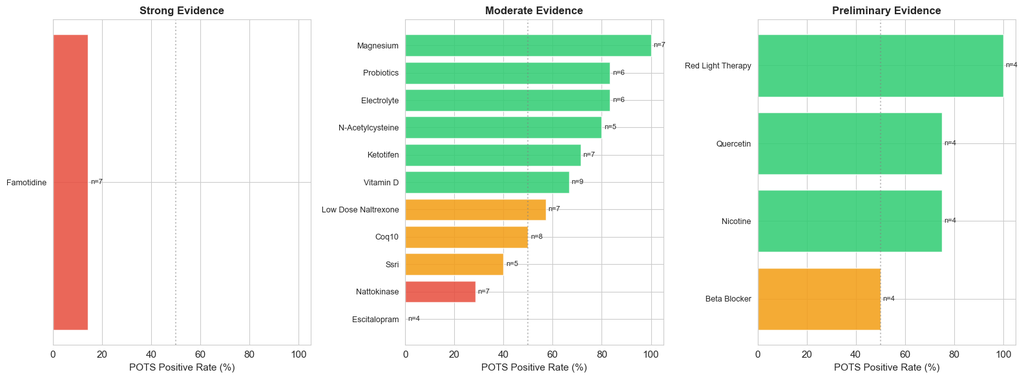

**How to read the tiers:**

- **Strong evidence:** Enough POTS users reported (n>=7) AND the difference from baseline is statistically significant. These are the most reliable signals.
- **Moderate evidence:** Either sufficient sample (n>=5) or approaching significance (p<0.10). Directionally informative but not conclusive.
- **Preliminary evidence:** Fewer than 5 POTS users reported. Signals only -- not enough data to draw any conclusions. Included for completeness.

## 13. Sensitivity Analysis

Does the main finding -- POTS users report worse outcomes -- survive if we restrict to strong-signal reports only (excluding weak signal-strength extractions)?

| Analysis | POTS Mean Sentiment | Non-POTS Mean Sentiment | Mann-Whitney p | r<sub>rb</sub> |
| --- | --- | --- | --- | --- |
| All reports | 0.182 (n=51) | 0.394 (n=1070) | 0.0022 | 0.244 |
| Strong/Moderate signal only | 0.105 (n=44) | 0.307 (n=936) | 0.0347 | 0.181 |

## 14. Conclusion

POTS users in the Long COVID community are not merely "Long COVID patients with one extra symptom." They represent a distinct, high-burden subgroup with a qualitatively different experience of illness and treatment.

For a POTS patient asking "what should I try?", this data suggests starting with low-risk, well-tolerated options that address autonomic physiology directly: magnesium supplementation, aggressive electrolyte management, and volume expansion strategies. Treatments targeting microclots (nattokinase) or histamine (famotidine) appear less effective for POTS specifically, though they may work well for non-POTS Long COVID patients. SSRIs should be approached with particular caution in POTS -- the escitalopram signal, while small, aligns with clinical literature on serotonergic medications worsening orthostatic symptoms.

The most important finding may be the one about the community itself: POTS users are disproportionately engaged, posting more, trying more treatments, and discussing their healthcare encounters at higher rates. This reflects both the severity of their condition and the inadequacy of current treatment paradigms. They are, in a sense, the community's most active experimenters -- and their collective experience deserves dedicated clinical attention.

Two questions this analysis cannot answer but should motivate follow-up work: (1) Do POTS users who manage their autonomic symptoms first (beta blockers, electrolytes, compression) respond better to subsequent Long COVID treatments? (2) Is the nattokinase failure specific to POTS, or does it reflect a broader pattern where treatments addressing one mechanism fail when the primary driver is autonomic?

## 15. Research Limitations

1. **Selection bias.** Reddit users skew younger, more tech-literate, and more English-speaking than the general POTS population. Users who post about POTS in a Long COVID community may not represent all POTS patients.
2. **Reporting bias.** Users are more likely to post about dramatic experiences (very positive or very negative) than about modest improvements. This inflates the tails of the sentiment distribution and may exaggerate differences between groups.
3. **Survivorship bias.** Users who leave the community (because they recovered, gave up, or died) are not represented. The active community is enriched for people still struggling, potentially inflating negative sentiment.
4. **Recall bias.** Treatment reports are retrospective self-assessments, not real-time diaries. Users may misremember timing, dosage, or response magnitude, especially for treatments tried months ago.
5. **Confounding.** POTS users have dramatically more comorbidities. Their worse treatment outcomes could reflect disease severity, polypharmacy interactions, or other confounders rather than POTS-specific treatment resistance.
6. **No control group.** There is no untreated comparison group. We compare POTS to non-POTS within the Long COVID community, not to healthy controls or to an appropriate clinical trial structure.
7. **Sentiment vs efficacy.** Self-reported sentiment is not a clinical outcome. "Positive sentiment" may reflect hope, expectation effects, or social desirability rather than measurable improvement. Conversely, "negative sentiment" may reflect unmet expectations rather than objective harm.
8. **Temporal snapshot.** This is one month of data. Treatment response patterns may shift with seasons, viral variants, community trends, or new treatment discoveries. The POTS treatment landscape in March-April 2026 may not generalize to other periods.

These findings reflect reporting patterns in online communities, not population-level treatment effects. This is not medical advice.